# Week 7: Multilevel Models

PS 818 - Statistical Models

Anton Strezhnev

strezhnev@wisc.edu

University of Wisconsin-Madison

October 13, 2025

$$\require{cancel}
\DeclareMathOperator*{\argmin}{arg\,min}$$

$$\DeclareMathOperator*{\argmax}{arg\,max}$$

# Previously

- **Stan**
  - **Hamiltonian Monte Carlo** - use the gradient of the likelihood $\times$ prior to get good M-H proposals
    - Avoids proposals that are either too auto-correlated and too likely to be rejected
  - Commmon structure to statistical modeling: `data`, `parameters`, `model`
  - Frequently used models have canned routines in `rstanarm` or `brms`
- **Diagnosing model fit**
  - Posterior predictive checks
  - **Information criteria** vs. **Cross-validation**
  - log-predictive density as a measure of prediction quality (how much probability mass do we place on the “correct” outcome)

# This week

- **Multilevel regression**
  - Extending the Bayesian GLM by adding additional **grouping** and structure
  - “Random effects” models/“Partial pooling”
- **Post-stratifiation**
  - Adjusting non-representative surveys to match population targets
  - Combining with multilevel regression: “MrP”
- **Dynamic regression**
  - Modeling dependence in the parameters over time

# Multilevel Models

# Hierarchical Models

- In our simple normal regression from before, we assumed both a common mean and intercept for the data.
  - The underlying model is the same regardless of which state an observation is located in.
- We also assumed that observations were completely exchangeable
  - $Y_i \sim \text{Normal}(X_i^{\prime}\beta, \sigma^2)$ implies no residual correlation in the outcomes across **all** counties.
- This may be a poor modeling choice if states are very heterogeneous and information about the state in which a county is in would provide additional predictive power beyond knowing the 2016 presidential vote.
  - Additionally, **exchangeability** of observations may be violated - unobserved factors may lead observations within a particular state to be correlated (e.g. if all counties in a region are exposed to some common shock).

# Hierarchical Models

- **Hierarchical** or **Multilevel** linear models try to address this by incorporating additional structure on the regression parameters.
  - Suppose observations belong to a group $j \in \{1, 2, 3, \dotsc, J\}$ (e.g. states, time periods, schools, etc…)
  - We observe $Y_{ij}$ as the outcome for unit $i$ in grouping $j$.
- We can incorporate group membership into the data-generating process.
- Instead of a **common prior** on $\beta \sim \text{Normal}(b_0, B_0^{-1})$, we may do something like:

  $$\beta_j \sim \text{Normal}(\mu_{\beta}, \Sigma_{\beta})$$

  $$Y_{ij} \sim \text{Normal}(X_{ij}^{\prime}\beta_{j}, \sigma^2)$$
- This model assumes that each group has it’s own set of group-level coefficients $\beta_j$ that are drawn from a common distribution centered at $\beta$.
- The choice of prior on $\beta$ then dictates the degree of **pooling** across groupings.
  - Flat prior: **no pooling** - $\beta_j$ are estimated entirely separately
  - Zero variance prior: complete pooling (all $\beta_j$ are equal to $\beta$)

# Hierarchical Models

- There are lots of choices about how we want to incorporate hierarchy into the model the coefficients across groupings
  - What levels of aggregation and how many?
  - Which parameters should be allowed to vary (all of the coefficients or just the intercepts)?
  - Where does the structure enter into the model (the means? the variances? the covariances?)

# Revisiting: Predicting Elections

```r
# Load the data
elections <- read_csv("data/us-house-wide.csv")

# Aggregate the house data to counties
elections_county <- elections %>% group_by(fipscode) %>% summarize(state=state[1], county=county[1],
                                                                   total.votes = sum(total.votes),
                                                                   dem = sum(dem))

# Merge in 2015 Presidential
pres_2016 <- read_csv("data/clinton_2016_vote.csv")
elections_county <- elections_county %>% left_join(pres_2016 %>% dplyr::select(county_fips, candidatevotes, totalvotes),
                                                   by=c(fipscode="county_fips"))

# Generate vote shares
elections_county$dem2018 <- elections_county$dem/elections_county$total.votes
elections_county$dem2016 <- elections_county$candidatevotes/elections_county$totalvotes

# Drop missing
elections_county <- elections_county %>% filter(!is.na(dem2018)&!is.na(dem2016))
```

```r
X_mat <- model.matrix(dem2018 ~ dem2016, data=elections_county)
Y <- elections_county$dem2018
K <- ncol(X_mat) # Number of beta parameters
```

# Application: Elections

- Let’s implement the “Normal Regression” model in Stan

```r
model_structure <- "
data {
  int N; // number of observations
  int K; // number of covariates
  matrix[N, K] X; //covariate matrix
  vector[N] y; //outcome vector
}
parameters {
  vector[K] beta; //regression coefficients
  real<lower = 0> sigma; // standard deviation
}
model {
  beta ~ normal(0, 3); // multivariate normal prior
  sigma ~ inv_gamma(0.001/2, 0.001/2); // inverse gamma
  y ~ normal(X * beta, sigma); // * is matrix multiplication if terms are matrices
}
generated quantities {
  array[N] real y_rep = normal_rng(X * beta, sigma);
  vector[N] log_lik;
  for (n in 1:N) log_lik[n] = normal_lpdf(y[n] | X[n, ] * beta, sigma);
}
"
```

# Application: Elections

- Load the relevant packages
- Pass the actual parameters as a list

# Application: Elections

- Run Stan!

```r
model_fit <- stan(
  model_code = model_structure,  # Stan code
  data = data_source,    # named list of data
  chains = 4,             # number of Markov chains
  warmup = 50,          # number of warmup iterations per chain
  iter = 2500,            # total number of iterations per chain
  cores = 4,              # number of cores (could use one per chain - by default uses however many you have)
  refresh = 0,          # no progress shown
  seed = 53703
  )
```

# Leave-one-out CV

- Once specified, we can obtain an estimate of the expected log predictive accuracy

```
            Estimate        SE
elpd_loo  4268.71291 115.52636
p_loo       55.88461  23.44207
looic    -8537.42581 231.05273
```

# Varying intercepts model

- Our regression from before is an example of a fully pooled regression.
  - Within individual states though, the regression line may be a poor predictor
  - The simplest fix is to allow the “intercept” to shift across units.
- Assume:

$$Y_{ij} \sim \text{Normal}(X_{ij}^{\prime}\beta + \alpha_{j}, \sigma^2)$$
$$\alpha_j \sim \text{Normal}(0, \sigma^2_\alpha)$$

- $\alpha_j$ can be interpreted as the group-specific “shift” in the intercept from the “grand” intercept $\beta_0$
  - An equivalent parameterization would be to remove the intercept from $\beta$ and write $\alpha_j \sim Normal(\mu_\alpha, \Sigma_\alpha)$

# Varying intercepts model

- Let’s implement this in Stan - first, our `data` block

```stan
data{
  int N; // number of observations
  int J; // Number of groups
  int K; // number of covariates
  array[N] int J_i; // group membership indicator
  matrix[N, K] X; //matrix of covariates
  vector[N] y; //outcome
}
```

# Varying intercepts model

- Next, our parameters.

```stan
parameters{
  vector[K] beta; // beta coefficients
  vector[J] alpha; // random intercepts
  real<lower = 0> sigma; // variance of outcome
  real<lower=0> sigma_a; // variance of intercepts
}
```

# Varying intercepts model

- Finally, our model

```stan
model{
  beta ~ normal(0, 3); // normal prior on coefficients
  alpha ~ normal(0, sigma_a); // normal distribution on random intercepts
  sigma ~ inv_gamma(0.001/2, 0.001/2);
  sigma_a ~ inv_gamma(0.001/2, 0.001/2);
  y ~ normal(alpha[J_i] + X*beta, sigma);
}
```

# Varying intercepts model

- Put it into Stan!

```r
elections_county$state_num <- as.numeric(as.factor(elections_county$state))
varying_intercepts_data <- list(N = nrow(X_mat), J = length(unique(elections_county$state_num)),
                    J_i = elections_county$state_num,
                    K = ncol(X_mat), X=X_mat, y=Y)
```

```r
model_var_intercept <- stan(
  model_code = varying_intercepts_model,  # Stan code
  data = varying_intercepts_data,    # named list of data
  chains = 4,             # number of Markov chains
  warmup = 500,          # number of warmup iterations per chain
  iter = 2500,            # total number of iterations per chain
  cores = 4,              # number of cores (this is much slower if = 1)
  refresh = 0,          # no progress shown
  seed = 53703          # random seed
  )
```

# Varying intercepts model

- Summarize the fit

```r
print(model_var_intercept, pars = c("beta","sigma","alpha[1]"))
```

```
Inference for Stan model: anon_model.
4 chains, each with iter=2500; warmup=500; thin=1;
post-warmup draws per chain=2000, total post-warmup draws=8000.

         mean se_mean   sd 2.5%  25%  50%  75% 97.5% n_eff Rhat
beta[1]  0.04       0 0.01 0.03 0.04 0.04 0.04  0.05   467 1.01
beta[2]  1.07       0 0.01 1.05 1.06 1.07 1.07  1.08  8913 1.00
sigma    0.05       0 0.00 0.05 0.05 0.05 0.05  0.05  8905 1.00
alpha[1] 0.02       0 0.01 0.01 0.02 0.02 0.03  0.04   837 1.01

Samples were drawn using NUTS(diag_e) at Wed Oct 15 00:34:53 2025.
For each parameter, n_eff is a crude measure of effective sample size,
and Rhat is the potential scale reduction factor on split chains (at
convergence, Rhat=1).
```

# Posterior predictive check

- Pull the `y_rep` from the model (in the form of a list)

```r
y_ppc_varint <- rstan::extract(model_var_intercept)$y_rep
```

- Calculate the upper and lower credible intervals

```r
y_ppc_ci_varint <- t(apply(y_ppc_varint, 2, function(x) quantile(x, c(.025, .975))))
```

- What’s the share that cover the truth?

```r
cover_95_varint <- y_ppc_ci_varint[,1]<Y&Y<y_ppc_ci_varint[,2]
mean(cover_95_varint)
```

```
[1] 0.963
```

# Posterior predictive check

- Empirical density vs. predicted

```r
bayesplot::ppc_dens_overlay(y = elections_county$dem2018, yrep = y_ppc_varint[1:25,])
```

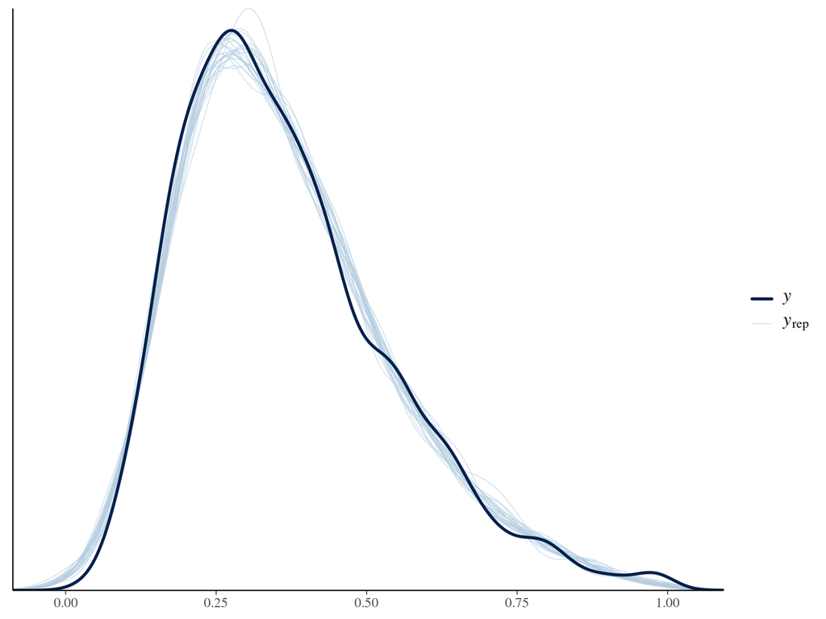

# Posterior predictive check

- What’s the root mean squared deviation from the truth?

```r
sqd_error_varint <- apply((Y - t(y_ppc_varint))^2, 2, mean)
print(sqrt(mean(sqd_error_varint)))
```

```
[1] 0.0693
```

- Make a dataframe for the predictive “ribbon” plot

```r
elections_county$lowerppdVI <- y_ppc_ci_varint[,1]
elections_county$upperppdVI <- y_ppc_ci_varint[,2]
```

# Outcome plots

- Compare the two regression lines

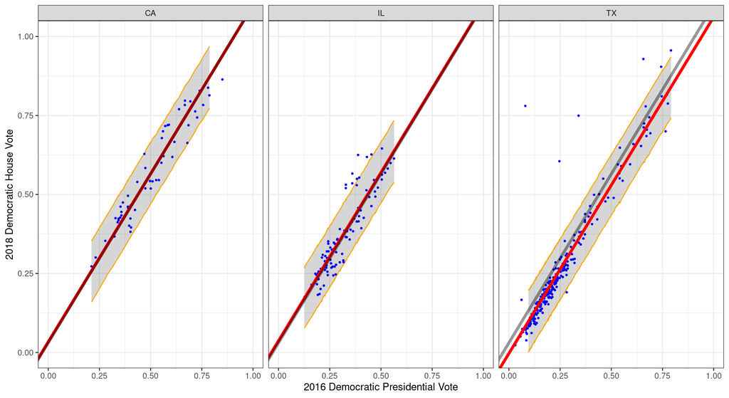

# Leave-one-out statistic

- Calculate the leave-one-out statistic

```r
loo_varint <- loo(model_var_intercept, pars="log_lik")
loo_varint$estimates
```

```
         Estimate    SE
elpd_loo   4854.9 162.3
p_loo        61.5  10.3
looic     -9709.9 324.6
```

```r
loo_compare(loo_varint, loo_reg)
```

```
       elpd_diff se_diff
model1    0.0       0.0
model2 -586.2      62.9
```

# Varying intercepts model

- Plot the deviations from the “grand mean” intercept by state

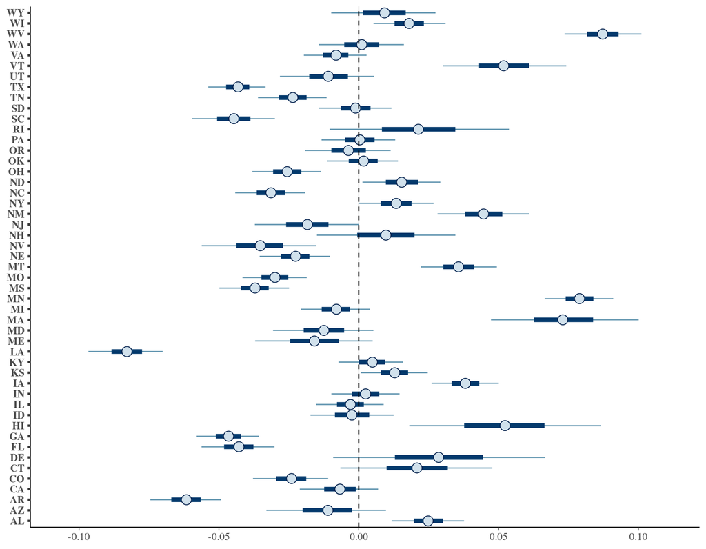

# Varying slopes model

- What if we allow all of the parameters to vary by group?

  $$\beta_j \sim \text{Normal}(\mu_{\beta}, \Sigma_{\beta})$$
  $$Y_{ij} \sim \text{Normal}(X_{ij}^{\prime}\beta_{j}, \sigma^2)$$
- This is a more general and flexible hierarchical model
  - But introduces a slight complication – we now need a prior distribution on an entire **matrix** $\Sigma_{\beta}$ (the variances and covariances of the parameters).
- The conjugate prior is the inverse-Wishart, the multivariate extension of the inverse-gamma.
  - An alternative non-conjugate prior (that appears to have better performance) is a scaled correlation matrix with an LKJ prior on the correlation matrix (see Stan documentation for more).
  - The latter is now preferred (especially by the Stan programmers)

# Varying slopes model

- Our prior on $\Sigma_{\beta}$ starts by decomposing $\Sigma_{\beta}$ into a diagonal scaling matrix $\text{diag}(\tau)$ and a correlation matrix $\Omega$

  $$\Sigma_{\beta} = \text{diag}(\tau)\Omega\text{diag}(\tau)$$
- For each $\tau_k$ we’ll use a Half-Cauchy distribution (Cauchy with the constraint $\tau_k > 0$)
- For $\Omega$, we’ll use the Lewandowski-Kurowicka-Joe (LKJ) distribution which defines a distribution over symmetric positive definite matrices
  - **Intuition**: Similar to a beta distribution in multiple dimensions.

# Varying slopes model

- Our `data` block

```stan
data{
  int N; // number of observations
  int J; // Number of groups
  int K; // number of covariates
  array[N] int J_i; // group membership indicator
  matrix[N, K] X; //matrix of covariates
  vector[N] y; //outcome
```

# Varying slopes model

- Our `parameters` field

```stan
parameters{
  corr_matrix[K] Omega; //prior correlation
  vector<lower=0>[K] tau; //prior scale
  vector[K] mu_beta;
  array[J] vector[K] beta; //group-level coefficients
  real<lower = 0> sigma; // variance parameters
}
```

# Varying slopes model

- And our `model`

```stan
model{
  tau ~ cauchy(0, 2.5);
  Omega ~ lkj_corr(2);
  sigma ~ inv_gamma(0.001/2, 0.001/2); //Inverse-gamma
  mu_beta ~ normal(0, 3);
  beta ~ multi_normal(mu_beta, quad_form_diag(Omega, tau));
  for (n in 1:N) {
    y[n] ~ normal(X[n] * beta[J_i[n]], sigma);
  }
}
```

# Varying slopes model

- Run it in Stan

```r
model_var_slope <- stan(
  model_code = varying_slopes,  # Stan code
  data = varying_intercepts_data,    # named list of data
  chains = 4,             # number of Markov chains
  warmup = 500,          # number of warmup iterations per chain
  iter = 2500,            # total number of iterations per chain
  cores = 4,
  refresh=0,          # no progress shown
  seed = 53703        # random seed
  )
```

# Varying slopes model

- Summarize the fit

```r
print(model_var_slope, pars=c("mu_beta"))
```

```
Inference for Stan model: anon_model.
4 chains, each with iter=2500; warmup=500; thin=1;
post-warmup draws per chain=2000, total post-warmup draws=8000.

           mean se_mean   sd 2.5%  25%  50%  75% 97.5% n_eff Rhat
mu_beta[1] 0.04       0 0.01 0.03 0.04 0.04 0.05  0.06  6772    1
mu_beta[2] 1.06       0 0.02 1.02 1.04 1.06 1.07  1.09  6953    1

Samples were drawn using NUTS(diag_e) at Wed Oct 15 00:39:09 2025.
For each parameter, n_eff is a crude measure of effective sample size,
and Rhat is the potential scale reduction factor on split chains (at
convergence, Rhat=1).
```

# Varying slopes model

- Pull the `y_rep` from the model (in the form of a list)

```r
y_ppc_varslope <- rstan::extract(model_var_slope)$y_rep
```

- Calculate the upper and lower credible intervals

```r
y_ppc_ci_varslope <- t(apply(y_ppc_varslope, 2, function(x) quantile(x, c(.025, .975))))
```

- What’s the share that cover the truth?

```r
cover_95_varint <- y_ppc_ci_varslope[,1]<Y&Y<y_ppc_ci_varslope[,2]
mean(cover_95_varint)
```

```
[1] 0.965
```

# Empirical density

- Posterior predictions vs. empirical density

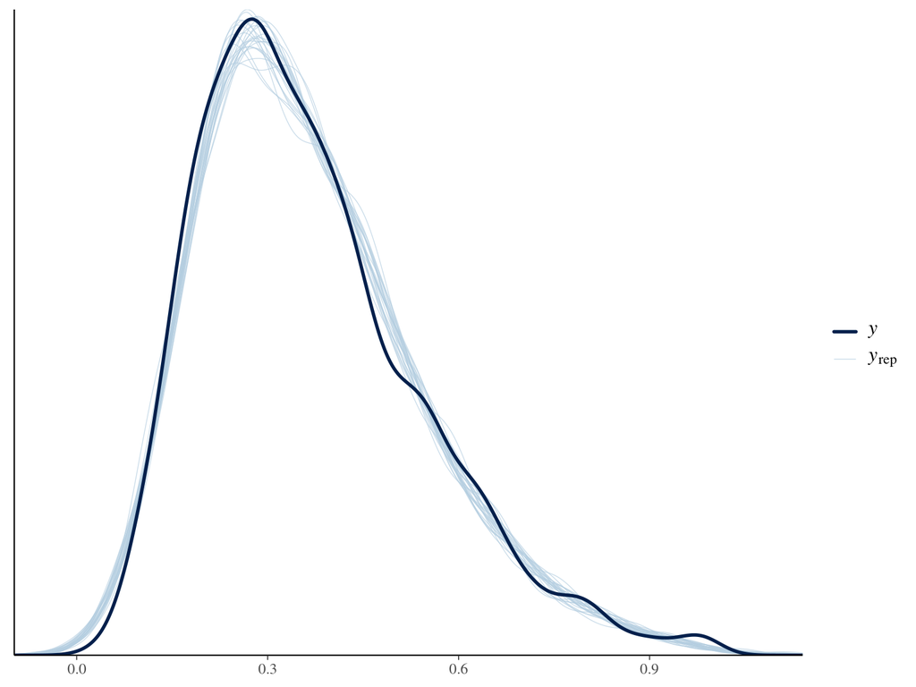

# Outcome plots

- Compare the regression lines

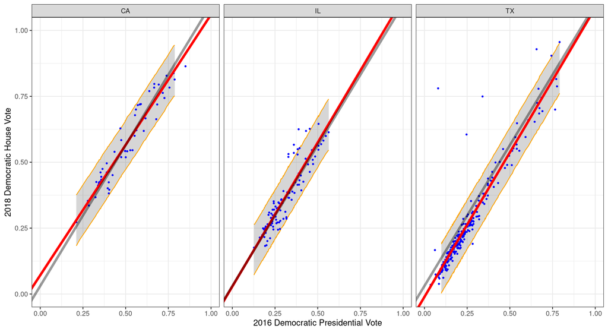

# Leave-one-out statistic

- Calculate the leave-one-out statistic

```r
loo_varslope <- loo(model_var_slope, pars="log_lik")
loo_varslope$estimates
```

```
         Estimate    SE
elpd_loo     4933 169.7
p_loo         101  14.9
looic       -9865 339.5
```

```r
loo_compare(loo_varslope ,loo_varint, loo_reg)
```

```
       elpd_diff se_diff
model1    0.0       0.0
model2  -77.7      28.5
model3 -663.9      75.8
```

# Multilevel Regression and Post-stratification

- Often we’re interested in estimating political attitudes at very small areas
  - Within a nationally-representative sample, we may only have a minor fraction of respondents who are even in a particular region.
- Beyond that, our sample may not be demographically representative for a given region
  - Can we do better than just using the sub-group means for our outcome of interest?

# MrP

- **Multilevel Regression** and **Post-stratification** combines two well-known tools to try to accomplish this task
  1. **Multilevel regression**: Using the entire dataset, specify a flexible model for the outcome of interest
  2. **Post-stratification**: Using known population characteristics, generate predictions for each covariate “cell” in each region
- The national-level regression allows us to improve **precision** in small-area estimation
  - e.g. if some of the variability between regions is driven by individual or group-level characteristics, we can model the relationship between those characteristics and the outcome using **all** the data.
- The population-level data allows us to address non-response/sampling bias
  - Ideally all of the variables that would go in the survey weighting model also go in the MrP model (so in principle we don’t need to include survey weights in the analysis)

# MrP Workflow

1. Get survey data that contains individual and group-level predictors (e.g. demographic characteristics + “small area” of residence)
2. Get information on the “small areas” themselves
3. Estimate a multilevel regression model using these two sets of data
4. Construct a post-stratification frame that has the joint distribution of our demographics for each “small area”
5. Predict using the model for each cell in the post-stratification frame
6. Aggregate to get predictions for each small area

# Post-stratification

- The easiest approach to adjusting a non-representative survey is to weight to match the **known** **joint** distribution of $x$ in the population $f_{\mathcal{U}}(\mathbf{x})$
  - This requires a lot of auxiliary information about the target - typically obtained from high-quality census data
  - (e.g.) U.S. Census Public-Use Microdata: What is the share of Black, college educated, 30-45 year olds in Massachusetts?
- In post-stratification, we divide our sample up into $C$ **cells** $c$ that are mutually exclusive and exhaustive.
  - $\tilde{T}_{\mathbf{x}} = \{\tilde{P}_{1}, \tilde{P}_2, \dotsc, \tilde{P}_{C}\}$ is our population distribution of these cells
- Our **sampling/response model** assumes that **within** each of these cells we have a simple-random sample from that particular stratum of the population
  - There may be variation in non-response or over/under-sampling, but only **across** cells
  - “post”-stratification because the intuition is akin to a design where we actually *did* stratify ex-ante
- Our **measurement model** assumes we observe the joint distribution of auxiliary variables $\mathbf{x}$ in the target population
  - Difficult in many cases!

# Post-stratification

- Two ways to think of post-stratification:
- **First** - Let $\hat{\theta}_{y}^{c}$ denote our estimator for the population mean **within** cell $c$
  - Then, our post-stratification estimator $\hat{\theta}_{y}^{PS}$ is:

$$\hat{\theta}_{y}^{PS} = \sum_{c=1}^C \tilde{P}_{c} \hat{\theta}_{y}^{c}$$

- Alternatively, we’ll sometimes write $\tilde{P}_c = \frac{\tilde{N}_c}{\tilde{N}}$ where $\tilde{N}$ is the size of the population and $\tilde{N}_c$ is the number of units in that cell.

$$\hat{\theta}_{y}^{PS} = \sum_{c=1}^C \frac{\tilde{N}_c}{\tilde{N}} \hat{\theta}_{y}^{c}$$

- Fixed “constant” weights on the within-cell estimators.

# Post-stratification

- **Second** - We can think of it as weighting individual observations using our adjustment weights $\tilde{w}^{PS}_i$
- Let $c(i)$ denote the class to which unit $i$ belongs. Then the post-stratification weights are

$$\tilde{w}^{PS}_i = (\tilde{P}_{c(i)}/\hat{P}^{S}_{c(i)}) \times d_i$$

where $\hat{P}^{S}_{c(i)}$ is the estimated **in-sample** proportion of observations in class $c$

- When design weights are constant, $\hat{P}^{S}_{c(i)}$ is just the sample mean of the indicator of class membership $\mathcal{1}_{i \in c}$
  - More generally, you can write it as $\hat{P}^{S}_{c(i)} = (\sum_{i=1}^N d_i \mathcal{1}_{i \in c})/(\sum_{i=1}^N d_i)$
- **Intuition**
  - The weights **up-weight** observations that are under-represented in the sample relative to the target population
  - The weights **down-weight** observations that are over-represented in the sample relative to the target population.

# Example: CCES 2020

- Our **unweighted** average Trump approval in the 2020 CCES for each state:

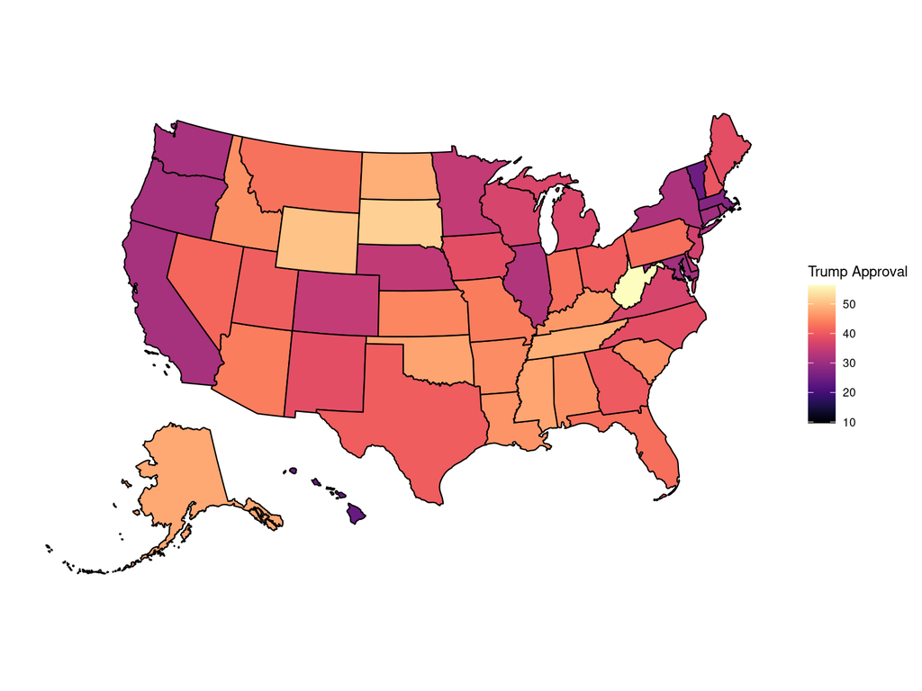

# Example: CCES 2020

- Let’s fit a regression model
  - We’ll use the `brms` package which has pre-existing implementations of popular models like the random slopes/random intercepts generalized linear mixed model
- We’ll fit a simple logistic regression with coefficients on gender, age and education as well as a random intercept for state

```r
state_mlm <- brm(trumpApprove ~ factor(gender_bin) + factor(age_bin) + factor(educ_bin) +  (1 | inputstate),
                           family = bernoulli(), data=cces, cores=4, warmup=1000, iter=2000)
```

# Model diagnostics

- Summarize the results

```
 Family: bernoulli
  Links: mu = logit
Formula: trumpApprove ~ factor(gender_bin) + factor(age_bin) + factor(educ_bin) + (1 | inputstate)
   Data: cces (Number of observations: 60968)
  Draws: 4 chains, each with iter = 2000; warmup = 1000; thin = 1;
         total post-warmup draws = 4000

Multilevel Hyperparameters:
~inputstate (Number of levels: 51)
              Estimate Est.Error l-95% CI u-95% CI Rhat Bulk_ESS Tail_ESS
sd(Intercept)     0.32      0.04     0.26     0.41 1.01      517     1132

Regression Coefficients:
                           Estimate Est.Error l-95% CI u-95% CI Rhat Bulk_ESS
Intercept                     -1.31      0.05    -1.41    -1.21 1.02      349
factorgender_binMale           0.41      0.02     0.38     0.45 1.00     3839
factorage_bin30M44             0.23      0.03     0.17     0.28 1.00     2043
factorage_bin45M64             0.58      0.03     0.53     0.63 1.00     1910
factorage_bin65P               0.76      0.03     0.71     0.81 1.00     2070
factoreduc_binH.S.orless       0.61      0.02     0.56     0.66 1.00     1955
factoreduc_binPostgraduate    -0.38      0.03    -0.44    -0.31 1.00     2226
factoreduc_binSomecollege      0.30      0.02     0.25     0.34 1.00     2244
                           Tail_ESS
Intercept                       849
factorgender_binMale           2891
factorage_bin30M44             2489
factorage_bin45M64             2545
factorage_bin65P               2712
factoreduc_binH.S.orless       2251
factoreduc_binPostgraduate     2407
factoreduc_binSomecollege      2502

Draws were sampled using sampling(NUTS). For each parameter, Bulk_ESS
and Tail_ESS are effective sample size measures, and Rhat is the potential
scale reduction factor on split chains (at convergence, Rhat = 1).
```

# Model diagnostics

- Check convergence

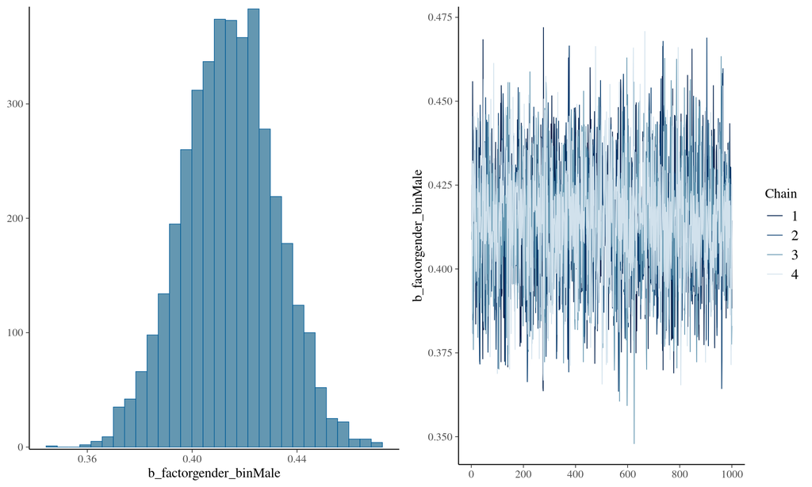

# Generating the post-stratification frame

- We’ll use ACS 5-year microdata data at the state level to construct our post-stratification frame for each state

```r
acs_state_targets <- read_csv("data/ACS_2020_microdata_by_state.csv") %>% filter(!is.na(Gender))
fips_codes <- read_csv("data/us-state-ansi-fips.csv")
acs_state_targets <- acs_state_targets %>% left_join(fips_codes, by=c(State="stname"))
acs_state_targets$inputstate <- as.numeric(acs_state_targets$st)
acs_state_targets <- acs_state_targets %>% pivot_longer(c(`18-29`, `30-44`, `45-64`, `65+`))
acs_state_targets <- acs_state_targets %>% rename(gender_bin = Gender, educ_bin = Education, age_bin = name, Count=value)
acs_state_targets <- acs_state_targets %>% mutate(prop_us = Count/sum(Count))
acs_state_targets <- acs_state_targets %>% group_by(inputstate) %>% mutate(prop_state = Count/sum(Count)) %>% ungroup()
```

# Generating the post-stratification frame

- Each row contains a row for each **state** x **age** x **gender** x **education** combination

```r
kable(head(acs_state_targets))
```

| State | gender_bin | educ_bin | st | stusps | inputstate | age_bin | Count | prop_us | prop_state |
| --- | --- | --- | --- | --- | --- | --- | --- | --- | --- |
| Alabama | Male | H.S. or less | 01 | AL | 1 | 18-29 | 195648 | 0.001 | 0.051 |
| Alabama | Male | H.S. or less | 01 | AL | 1 | 30-44 | 198528 | 0.001 | 0.052 |
| Alabama | Male | H.S. or less | 01 | AL | 1 | 45-64 | 294365 | 0.001 | 0.077 |
| Alabama | Male | H.S. or less | 01 | AL | 1 | 65+ | 168153 | 0.001 | 0.044 |
| Alabama | Male | Some college | 01 | AL | 1 | 18-29 | 148968 | 0.001 | 0.039 |
| Alabama | Male | Some college | 01 | AL | 1 | 30-44 | 129718 | 0.001 | 0.034 |

# Predicting with the model

- Use the model to make predictions on each row of our post-stratification frame

```r
acs_state_targets$predict_mlm <- predict(state_mlm, newdata=acs_state_targets)[,1]
```

- Aggregate the predictions by the stratum shares to get state-level estimates!

```r
mrp_states <- acs_state_targets %>% group_by(st) %>% summarize(trumpApproveMLM = sum(predict_mlm*prop_state)*100) %>% rename(fips=st)
```

# Compare

- Use the model to make predictions on each row of our post-stratification frame

```r
state_summaries %>% left_join(mrp_states, by="fips")
```

```
# A tibble: 51 × 3
   fips  values trumpApproveMLM
   <chr>  <dbl>           <dbl>
 1 01     45.6             49.0
 2 02     47.8             47.2
 3 04     43.7             44.2
 4 05     45.1             47.0
 5 06     31.2             33.5
 6 08     34.5             35.6
 7 09     30.4             31.7
 8 10     33.8             36.3
 9 11      9.64            16.1
10 12     42.2             44.2
# ℹ 41 more rows
```

# Visualize

- Our **multilevel regression + post-stratification** estimates

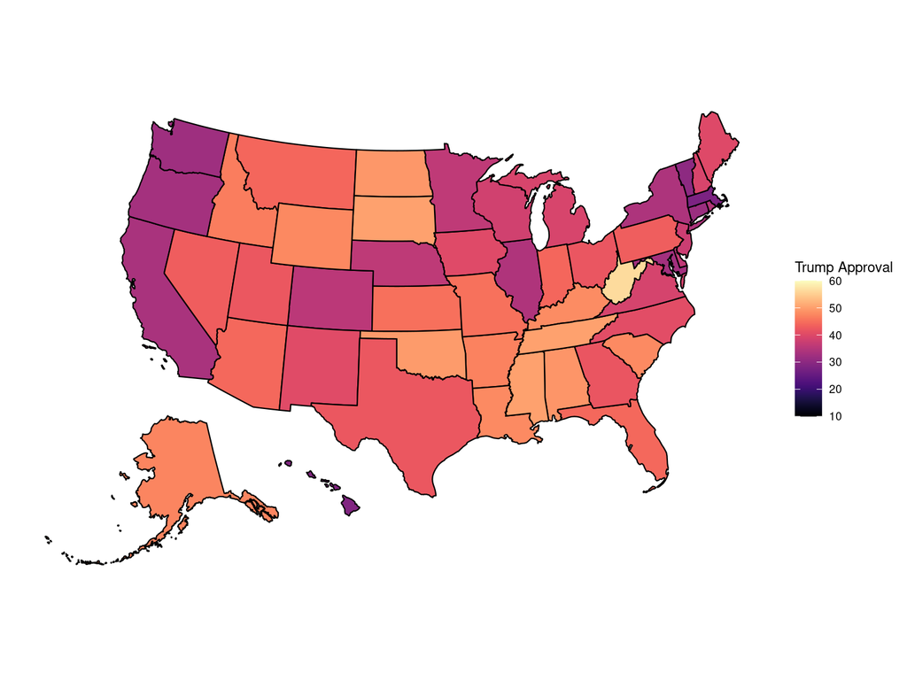

# Visualize

- Compare with unweighted

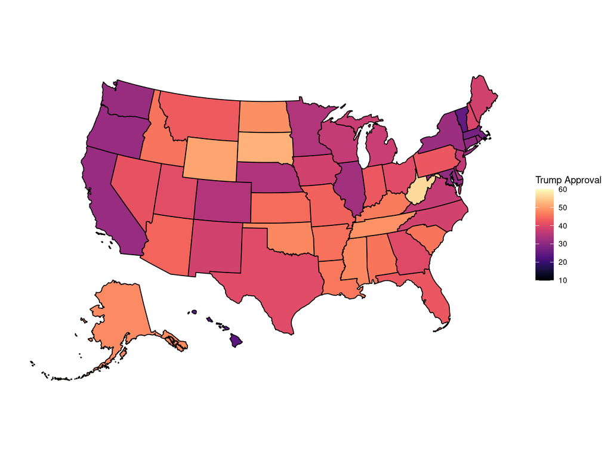

# How to improve this model

- We’ve provided a very simple example of an MrP model but there are a lot of ways it can be improved
  1. More group-level predictors (e.g. Trump state-level vote share)
  2. Individual-level interactions in the model + partial-pooling on the coefficients
  3. Actually knowing the joint distribution of the demographics in each state!
  4. Pool state-level means to regional rather than a common “grand” mean.
  5. Many more possibilities…
- More generally, we have a dataset where even within each state, we have many observations to work with, so the model isn’t that necessary
  - MrP is most powerful when there are **very few** respondents from a particular small area in our data

# Dynamic Models

# Dynamic models

- Another way that we can impose **hierarchy** via prior structure is through **time**
  - Parameters at time $t$ and parameters at time $t-1$ should be **related** in some way.
- This idea appears in a lot of different places with a lot of different applications
  - Dynamic (linear/nonlinear) models
  - State-space models
  - Hidden Markov Models
- **Core modelling idea**
  - The outcome $Y_{it}$ is a function of some **error** $\epsilon_{it}$ and a **hidden state** $\theta_{t}$
  - The **hidden state** $\theta_{t}$ evolves as a function of $\theta_{t-1}$ and some other error $\omega_{t}$

# Dynamic linear model

- The **classic** linear form of the model
- **Outcome equation** $f(Y_t| \theta_t)$

  $$Y_{t} \sim \text{Normal}(\theta_{t}, \sigma^2_{Y})$$
- **Evolution equation** $f(\theta_t | \theta_{t-1})$

  $$\theta_{t} \sim \text{Normal}(\theta_{t-1}, \sigma^2_{\theta})$$
- We want to do inference on the posterior $f(\theta_t | Y)$

# Illustration - Simulated data

```r
set.seed(53703)
Time <- 50
sim_data <- data.frame(Time = 1:Time, Y= NA, theta = NA)
theta_0 <- 0
sigma_theta <- 2
sigma_Y <- 4
sim_data[1,]$theta <- rnorm(1, theta_0, sigma_theta)
sim_data[1,]$Y <- rnorm(1, sim_data[1,]$theta, sigma_Y)
for (t in 2:Time){
  sim_data[t,]$theta <- rnorm(1, sim_data[t-1,]$theta, sigma_theta)
  sim_data[t,]$Y <- rnorm(1, sim_data[t,]$theta, sigma_Y)
}
```

# Illustration - Stan code

```r
stan_dlm <- "data{
  int N; // number of time periods
  vector[N] y; // observed outcome
  real prior_sigma_Y; //scale parameter for sigma Y prior
  real prior_sigma_theta; //scale parameter for sigma theta prior
}
parameters{
  real<lower = 0> sigma_Y; // outcome variance
  real<lower = 0> sigma_theta; // smoothing variance
  vector[N] theta; // latent state
}
model{
  sigma_Y ~ cauchy(0, prior_sigma_Y);
  sigma_theta ~ cauchy(0, prior_sigma_theta);
  theta[1] ~ normal(0, sigma_theta);
  for (n in 2:N){
    theta[n] ~ normal(theta[n-1], sigma_theta);
  }
  for (n in 1:N){
    y[n] ~ normal(theta[n], sigma_Y);
  }
}
"
```

# Illustration - Stan

- Let’s try a relatively diffuse Cauchy prior (scale = $2.5$ for both)

```r
dlm_data <- list(y = sim_data$Y, N = length(sim_data$Y),
                 prior_sigma_Y = 2.5,
                 prior_sigma_theta = 2.5)
```

# Illustration - Stan

- Let’s get the estimated $\theta$ plus credible intervals

```r
theta_mat <- extract(model_dlm)$theta
theta_pm <- colMeans(theta_mat)
theta_95 <- apply(theta_mat, 2, function(x) quantile(x, c(.025, .975)))
```

# Illustration - Visualization

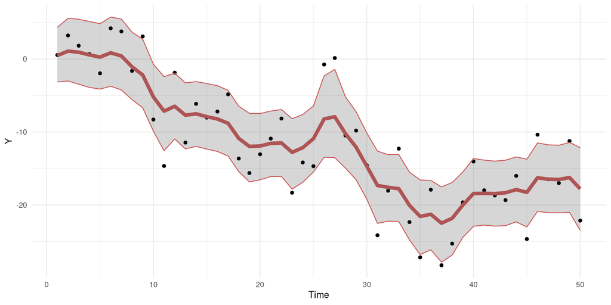

# Changing the prior

- What happens if instead of estimating the smoothing variance, we controlled it directly.

```r
stan_dlm_2 <- "data{
  int N; // number of time periods
  vector[N] y; // observed outcome
  real prior_sigma_Y; //scale parameter for sigma Y prior
  real<lower = 0>  sigma_theta; // smoothing parameter
}
parameters{
  real<lower = 0> sigma_Y; // outcome variance
  vector[N] theta; // latent state
}
model{
  sigma_Y ~ cauchy(0, prior_sigma_Y);
  theta[1] ~ normal(0, sigma_theta);
  for (n in 2:N){
    theta[n] ~ normal(theta[n-1], sigma_theta);
  }
  for (n in 1:N){
    y[n] ~ normal(theta[n], sigma_Y);
  }
}
"
```

# Changing the prior

```r
dlm_data_2 <- list(y = sim_data$Y, N = length(sim_data$Y),
                 prior_sigma_Y = 2.5,
                 sigma_theta = .5)
```

```r
theta_mat <- extract(model_dlm_tight)$theta
theta_pm <- colMeans(theta_mat)
theta_95 <- apply(theta_mat, 2, function(x) quantile(x, c(.025, .975)))
```

# Changing the prior

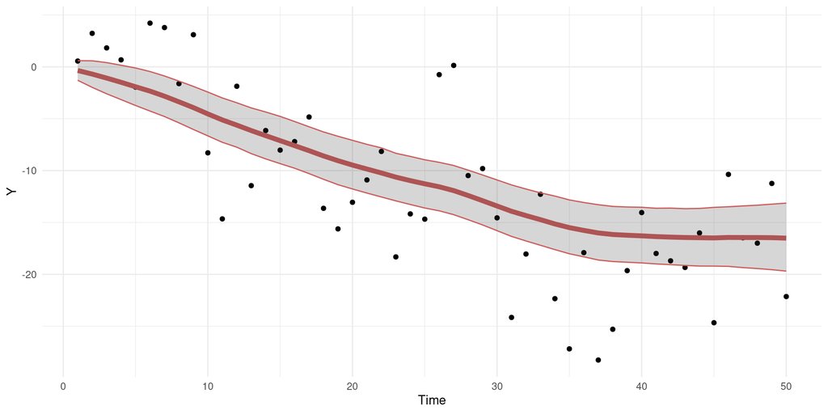

# Changing the prior

```r
dlm_data_3 <- list(y = sim_data$Y, N = length(sim_data$Y),
                 prior_sigma_Y = 2.5,
                 sigma_theta = 4)
```

```r
theta_mat <- extract(model_dlm_tight)$theta
theta_pm <- colMeans(theta_mat)
theta_95 <- apply(theta_mat, 2, function(x) quantile(x, c(.025, .975)))
```

# Changing the prior

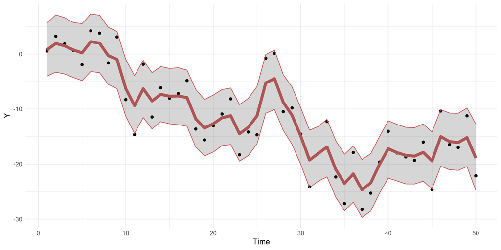

# Application: Polling Aggregation

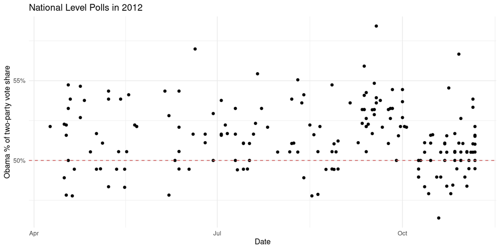

# Polling aggregation

- Polls are noisy measures of an underlying **truth**
  - Polling **aggregators** got a lot of traction (esp. in 2012) in summarizing these results
  - Developments in this industry focus on accounting for both **stochastic** error and **systematic** error
- One approach is to model the data as a **dynamic model**
  - We observe $N$ polls at $T$ total days ($t = T$ is election day)
  - A poll at time $t$ is a function of the **true** state of public opinion
  - Public opinion evolves from $t-1$ to $t$ as a **random walk**
- Since polls vary in sample size, we’ll use a **binomial** outcome model

  $$Y_i \sim \text{Binomial}(\theta_{i}, n_i)$$
- $Y_i$: The number of respondents supporting the **Democratic** candidate among respondents supporting one of the two major parties
- $n_i$: The number of poll respondents who support one of the two major parties (**observed constant**)
- $\theta_{i}$: Share supporting the Democratic candidate at in poll $i$

# Dynamic Binomial Model

- The parameter $\theta_i$ is going to be modeled as a function of some latent **state** variable observed at time $t$: $\mu_t$.
  - We’ll let $\mu_t$ be unbounded and use a logit link

$$\theta_i = \text{logit}^{-1}(\mu_{t[i]})$$

- We can add more to the logit link to model **poll-specific** characteristics (e.g. house-effects, quality adjustments, etc…)
- This is a simplified version of a full state-and-national model in **Linzer, D. A. (2013). Dynamic Bayesian forecasting of presidential elections in the states. Journal of the American Statistical Association, 108(501), 124-134.**
  - Extensions of this were used by The Economist, post-Silver 538 and now [FiftyPlusOne](https://fiftyplusone.news/))
  - For more info, see: [Heidemanns, M., Gelman, A., & Morris, G. E. (2020). An updated dynamic Bayesian forecasting model for the US presidential election. Harvard Data Science Review, 2(4).](https://sites.stat.columbia.edu/gelman/research/published/Harvard_Data_Science_Review.pdf)
  - Also check out the [old Github repository](https://github.com/TheEconomist/us-potus-model) for the actual model, old data and Stan code!

# Dynamic Binomial Model

- The **dynamic** part comes from our model on $\mu_{t}$. We assume a **random-walk prior**

  $$\mu_{t} | \mu_{t-1} \sim \text{Normal}(\mu_{t-1}, \sigma^2_{\mu})$$
- $\sigma^2_{\mu}$ is our smoothing parameter - can fix it or put a prior on it and estimate from the data
- We need to anchor one of the parameters for identification
  - Interestingly, we don’t need to always do $\mu_1$: **Linzer (2013)** anchors $\mu_{T}$ - the **election day** result.
  - Use a “fundamentals” forecast from *historical* elections $h$

  $$\mu_{T} \sim \text{Normal}(\text{logit}(h), \sigma_{h}^2)$$
- $\sigma_{h}^2$ governs how **strong** we want our final forecast to weigh the fundamentals model.
  - Low variance means **more** emphasis on “fundamentals”
  - High variance means **more** emphasis on polls.

# Dynamic Binomial Model

- [Lewis-Beck and Tien](https://papers.ssrn.com/sol3/papers.cfm?abstract_id=2110790) “Jobs model” gave Obama $47.61$ percent of the two-party vote-share using data from March, 2012
  - Inputs: Vote = Presidential Popularity, Economic Growth x Incumbent interaction, Jobs Creation, Incumbency Advantage
- We’ll use this as our prior mean $h_i$
  - We’ll pick prior variance as $\sigma_{h}^2 = .01$, but this is a tuning parameter that we can play with or try to learn from prior elections (which the forecasters do).

# Dynamic Binomial Model

```r
stan_elections <- "data{
  int Tm; // number of time periods
  int N; // number of polls
  array[N] int <lower = 1, upper = Tm> day; // day of poll
  array[N] int n_democrat; // votes for democrat
  array[N] int n_two_party; // votes for two-party candidates
  real h_prior; // historical forecast
  real<lower = 0> sigma_h; // historical forecast variance
}
parameters{
  vector[Tm] mu; // vote share
  real<lower = 0> sigma_mu; // smoothing parameter
}
model{
  sigma_mu ~ cauchy(0, 1);
  // latent states
  mu[Tm] ~ normal(logit(h_prior), sigma_h);
  for (time in 2:Tm){
    mu[time] ~ normal(mu[time - 1], sigma_mu);
  }
  // observed polls
  for (n in 1:N){
    n_democrat[n] ~ binomial_logit(n_two_party[n], mu[day[n]]);
  }
}
"
```

# Data prep

```r
polls2012$n_democrat <- round(polls2012$number.of.observations*(polls2012$obama/100))
polls2012$n_two_party <- round(polls2012$number.of.observations*((polls2012$obama + polls2012$romney)/100))
polls2012$end.date.num <- as.integer(polls2012$end.date)
polls2012$end.date.num <- polls2012$end.date.num - min(as.integer(polls2012$end.date)) + 1
election_day_num <- as.integer(ymd("2012-11-6")) - min(as.integer(polls2012$end.date)) + 1 #election day

stan_polling_data <- list(n_democrat = polls2012$n_democrat, n_two_party = polls2012$n_two_party,
                 Tm = election_day_num,
                 N = nrow(polls2012),
                 day = polls2012$end.date.num,
                 h_prior = .4761, # Lewis-Beck and Tien March, 2012 forecast
                 sigma_h = sqrt(.01))
```

# Running the model

```r
model_elections <- stan(
  model_code = stan_elections,  # Stan code
  data = stan_polling_data,    # named list of data
  chains = 4,             # number of Markov chains
  warmup = 500,          # number of warmup iterations per chain
  iter = 5000,            # total number of iterations per chain
  cores = 4,
  refresh=0,          # no progress shown
  seed = 53703        # random seed
  )
```

# Election Day Forecast

```r
inv.logit <- function(x) 1/(1 + exp(-x))
theta_mat <- extract(model_elections)$mu
theta_pm <- inv.logit(colMeans(theta_mat))
theta_95 <- inv.logit(apply(theta_mat, 2, function(x) quantile(x, c(.025, .975))))
forecasts <- data.frame(end.date.num = 1:election_day_num, est = theta_pm, lower95 = theta_95[1,], upper95 = theta_95[2,])
forecasts$end.date <- as.Date(forecasts$end.date.num +  min(as.integer(polls2012$end.date)) - 1)
kable(head(forecasts %>% arrange(-end.date.num)))
```

| end.date.num | est | lower95 | upper95 | end.date |
| --- | --- | --- | --- | --- |
| 212 | 0.511 | 0.504 | 0.518 | 2012-11-06 |
| 211 | 0.516 | 0.509 | 0.523 | 2012-11-05 |
| 210 | 0.511 | 0.501 | 0.521 | 2012-11-04 |
| 209 | 0.507 | 0.495 | 0.517 | 2012-11-03 |
| 208 | 0.504 | 0.494 | 0.514 | 2012-11-02 |
| 207 | 0.504 | 0.492 | 0.515 | 2012-11-01 |

# Forecast plot

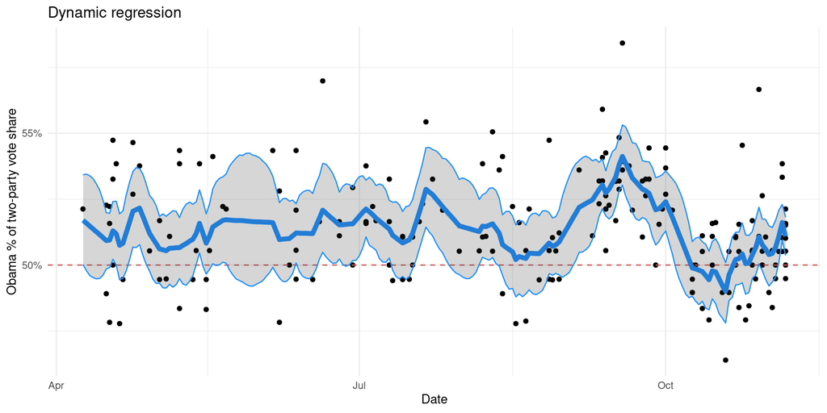

# Messing around with the prior on “fundamentals”

- What happens if we put a **really** strong weight on the fundamentals forecast over the polls?

```r
stan_polling_data_2 <- stan_polling_data
stan_polling_data_2$sigma_h <- sqrt(1/30000)
```

# Running the model

```r
model_elections <- stan(
  model_code = stan_elections,  # Stan code
  data = stan_polling_data_2,    # named list of data
  chains = 4,             # number of Markov chains
  warmup = 500,          # number of warmup iterations per chain
  iter = 5000,            # total number of iterations per chain
  cores = 4,
  refresh=0,          # no progress shown
  seed = 53703        # random seed
  )
```

# Election Day Forecast

```r
inv.logit <- function(x) 1/(1 + exp(-x))
theta_mat <- extract(model_elections)$mu
theta_pm <- inv.logit(colMeans(theta_mat))
theta_95 <- inv.logit(apply(theta_mat, 2, function(x) quantile(x, c(.025, .975))))
forecasts <- data.frame(end.date.num = 1:election_day_num, est = theta_pm, lower95 = theta_95[1,], upper95 = theta_95[2,])
forecasts$end.date <- as.Date(forecasts$end.date.num +  min(as.integer(polls2012$end.date)) - 1)
kable(head(forecasts %>% arrange(-end.date.num)))
```

| end.date.num | est | lower95 | upper95 | end.date |
| --- | --- | --- | --- | --- |
| 212 | 0.480 | 0.477 | 0.483 | 2012-11-06 |
| 211 | 0.515 | 0.507 | 0.522 | 2012-11-05 |
| 210 | 0.508 | 0.494 | 0.522 | 2012-11-04 |
| 209 | 0.502 | 0.489 | 0.516 | 2012-11-03 |
| 208 | 0.501 | 0.488 | 0.513 | 2012-11-02 |
| 207 | 0.500 | 0.485 | 0.514 | 2012-11-01 |

# Forecast plot

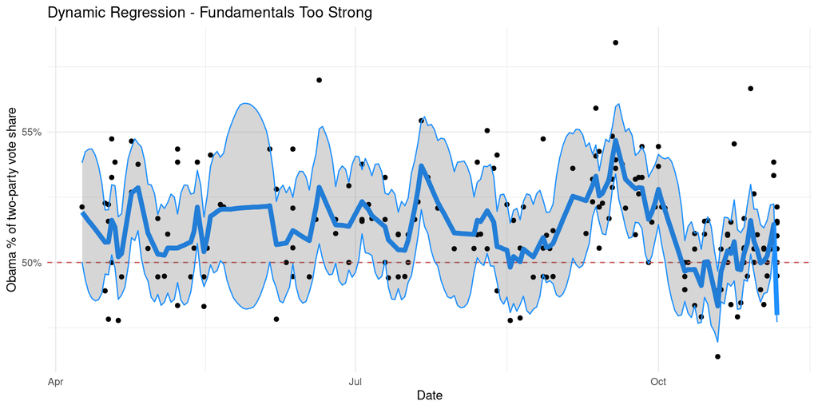

# Messing around with the smoother

- What if we played around with the smoothing variance directly and made it **smaller** - how would that change our forecast model?

```r
stan_elections_smoother <- "data{
  int Tm; // number of time periods
  int N; // number of polls
  array[N] int <lower = 1, upper = Tm> day; // day of poll
  array[N] int n_democrat; // votes for democrat
  array[N] int n_two_party; // votes for two-party candidates
  real h_prior; // historical forecast
  real<lower = 0> sigma_h; // historical forecast variance
  real<lower = 0> sigma_mu; // smoothing parameter
}
parameters{
  vector[Tm] mu; // vote share
}
model{
  // latent states
  mu[Tm] ~ normal(logit(h_prior), sigma_h);
  for (time in 2:Tm){
    mu[time] ~ normal(mu[time - 1], sigma_mu);
  }
  // observed polls
  for (n in 1:N){
    n_democrat[n] ~ binomial_logit(n_two_party[n], mu[day[n]]);
  }
}
"
```

# Messing around with the smoother

- What if we played around with the smoothing variance directly and made it **smaller** - how would that change our forecast model?

```r
stan_polling_data_3 <- stan_polling_data
stan_polling_data_3$sigma_mu <- .005
```

# Running the model

```r
model_elections <- stan(
  model_code = stan_elections_smoother,  # Stan code
  data = stan_polling_data_3,    # named list of data
  chains = 4,             # number of Markov chains
  warmup = 500,          # number of warmup iterations per chain
  iter = 5000,            # total number of iterations per chain
  cores = 4,
  refresh=0,          # no progress shown
  seed = 53703        # random seed
  )
```

# Election Day Forecast

```r
inv.logit <- function(x) 1/(1 + exp(-x))
theta_mat <- extract(model_elections)$mu
theta_pm <- inv.logit(colMeans(theta_mat))
theta_95 <- inv.logit(apply(theta_mat, 2, function(x) quantile(x, c(.025, .975))))
forecasts <- data.frame(end.date.num = 1:election_day_num, est = theta_pm, lower95 = theta_95[1,], upper95 = theta_95[2,])
forecasts$end.date <- as.Date(forecasts$end.date.num +  min(as.integer(polls2012$end.date)) - 1)
kable(head(forecasts %>% arrange(-end.date.num)))
```

| end.date.num | est | lower95 | upper95 | end.date |
| --- | --- | --- | --- | --- |
| 212 | 0.511 | 0.506 | 0.515 | 2012-11-06 |
| 211 | 0.511 | 0.506 | 0.515 | 2012-11-05 |
| 210 | 0.510 | 0.505 | 0.515 | 2012-11-04 |
| 209 | 0.509 | 0.504 | 0.514 | 2012-11-03 |
| 208 | 0.508 | 0.504 | 0.513 | 2012-11-02 |
| 207 | 0.508 | 0.503 | 0.513 | 2012-11-01 |

# Forecast plot

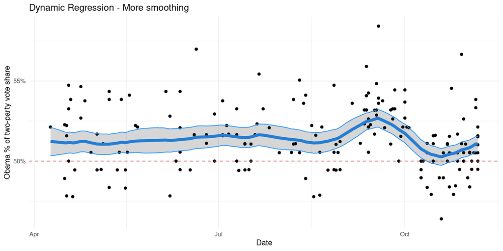

# Forecasting with partial data

- Let’s see how the model would have looked at just before the start of October?

```r
polls2012_september <- polls2012 %>% filter(end.date < ymd("2012-10-1"))
stan_polling_data_sept <- list(n_democrat = polls2012_september$n_democrat, n_two_party = polls2012_september$n_two_party,
                 Tm = election_day_num,
                 N = nrow(polls2012_september),
                 day = polls2012_september$end.date.num,
                 h_prior = .4761, # Lewis-Beck and Tien March, 2012 forecast
                 sigma_h = sqrt(.01))
```

# Running the model

```r
model_elections <- stan(
  model_code = stan_elections,  # Stan code
  data = stan_polling_data_sept,    # named list of data
  chains = 4,             # number of Markov chains
  warmup = 500,          # number of warmup iterations per chain
  iter = 5000,            # total number of iterations per chain
  cores = 4,
  refresh=0,          # no progress shown
  seed = 53703        # random seed
  )
```

# Election Day Forecast

```r
inv.logit <- function(x) 1/(1 + exp(-x))
theta_mat <- extract(model_elections)$mu
theta_pm <- inv.logit(colMeans(theta_mat))
theta_95 <- inv.logit(apply(theta_mat, 2, function(x) quantile(x, c(.025, .975))))
forecasts <- data.frame(end.date.num = 1:election_day_num, est = theta_pm, lower95 = theta_95[1,], upper95 = theta_95[2,])
forecasts$end.date <- as.Date(forecasts$end.date.num +  min(as.integer(polls2012$end.date)) - 1)
kable(head(forecasts %>% arrange(-end.date.num)))
```

| end.date.num | est | lower95 | upper95 | end.date |
| --- | --- | --- | --- | --- |
| 212 | 0.498 | 0.458 | 0.533 | 2012-11-06 |
| 211 | 0.499 | 0.458 | 0.534 | 2012-11-05 |
| 210 | 0.499 | 0.459 | 0.535 | 2012-11-04 |
| 209 | 0.500 | 0.459 | 0.535 | 2012-11-03 |
| 208 | 0.500 | 0.460 | 0.536 | 2012-11-02 |
| 207 | 0.501 | 0.460 | 0.536 | 2012-11-01 |

# Forecast plot

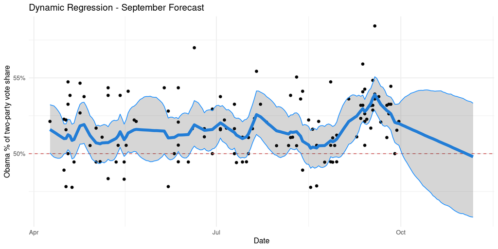